# Worksheet 6

Gabriel Singer

19.12.2023/31.01.2024

## Membrane composition of bacteria

Data source: Hall, Singer, Kainz & Lennon 2010. Functional Ecology 24: 898-908 Two bacterial isolates (a warm water and a cold water isolate) were exposed to two different cultivation temperatures (6 and 28 °C). We measured fatty acid composition of their membranes to investigate which fatty acids can be interpreted as adaptation (across isolates but same temperature) and which ones as acclimation (within an isolate but across temperatures). The 17 fatty acids are proportional data ("relative abundances of various FAs).

We will need the ‘vegan’ package (a lot of ordinations coded by ecologists for ecologists). Some more classical ordinations like PCA are available in the package ‘MASS’.

```r
library(vegan)
library(MASS)

lipids<-read.table(file="data/BacterialMembrane.txt",header=TRUE)
names(lipids)
```

```
##  [1] "case"        "isolate"     "temperature" "FA1_SAnb"    "FA2_MU"
##  [6] "FA3_SAnb"    "FA4_SAb"     "FA5_SAb"     "FA6_SAnb"    "FA7_MU"
## [11] "FA8_SAb"     "FA9_SAnb"    "FA10_MU"     "FA11_SAb"    "FA12_SAnb"
## [16] "FA13_MUb"    "FA14_MU"     "FA15_SAnb"   "FA16_MU"     "FA17_MU"
## [21] "sum_MU"      "sum_SA"      "sum_SAbran"  "sum_SAnbran" "SA_branprop"
```

The names of these fatty acids point to (un)saturation and branched molecule structure with the abbreviations: MU = mono-unsaturated, SA = saturated, nb = non-branched, b = branched. The variable SA_branprop is the proportion of branched and saturated FAs. More double bonds and branched molecules require more space and increase membrane fluidity at cold temperature.

1. To warm up test for location differences in the variables SA_branprop and FA1_SAnb for warm isolates only, i.e. search for a possible acclimation reaction between incubation temperatures.

```r
lipids$temperature = factor(lipids$temperature)
lipids_w<-subset(lipids,subset=isolate=="warm")
t.test(SA_branprop~temperature,data=lipids_w)
```

```
##
##  Welch Two Sample t-test
##
## data:  SA_branprop by temperature
## t = 3.8571, df = 11.628, p-value = 0.002412
## alternative hypothesis: true difference in means is not equal to 0
## 95 percent confidence interval:
##  0.0329829 0.1193233
## sample estimates:
##  mean in group 6 mean in group 28
##        0.7037247        0.6275716
```

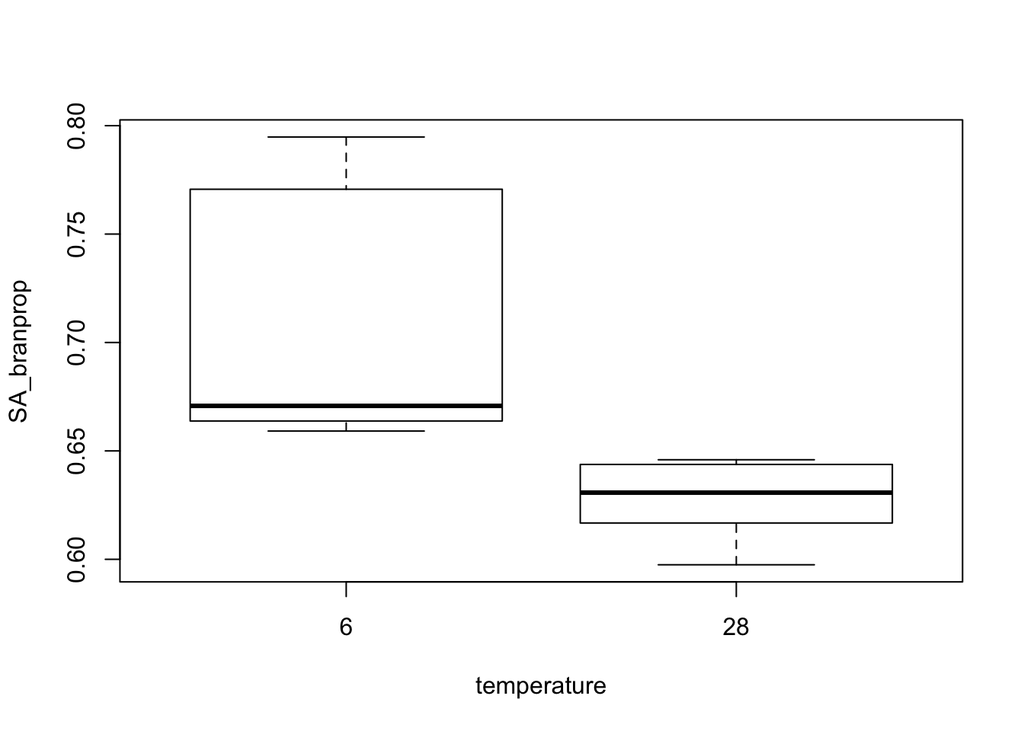

```r
boxplot(SA_branprop~temperature,data=lipids_w)
```

```r
t.test(FA1_SAnb~temperature,data=lipids_w)
```

```
##
##  Welch Two Sample t-test
##
## data:  FA1_SAnb by temperature
## t = -2.6971, df = 8.6538, p-value = 0.02536
## alternative hypothesis: true difference in means is not equal to 0
## 95 percent confidence interval:
##  -0.006487026 -0.000549202
## sample estimates:
##  mean in group 6 mean in group 28
##      0.003979397      0.007497511
```

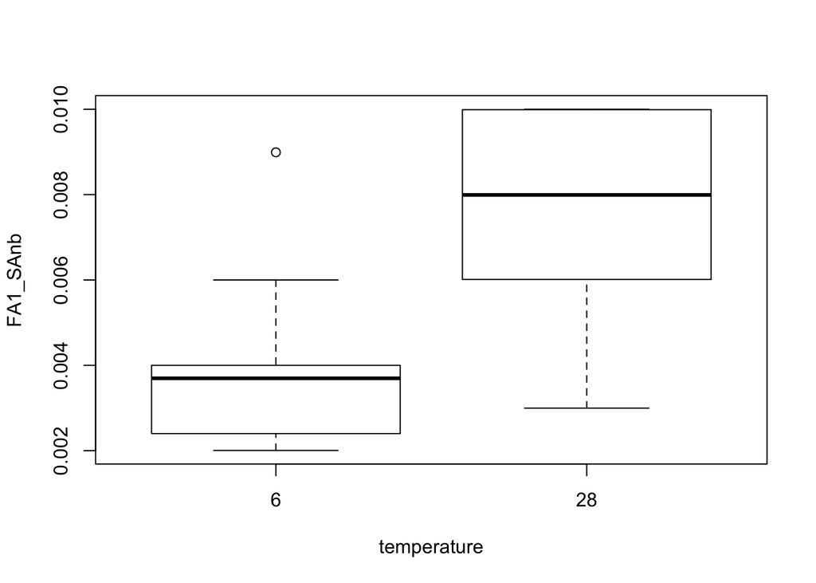

```r
boxplot(FA1_SAnb~temperature,data=lipids_w)
```

2. Assume you have forgotten how P-values for a two-sample location test are computed. Instead of relying on a fancy test statistic and a parameterized distribution giving you P-values for it, you can also test a null hypothesis by permutation of the data at hand. The assumption is simple: If the null hypothesis of identical means is correct, then assignment of the data to the samples is exchangeable. Any random assignment to the two groups is as good as the one observed. The question is how “extreme” is the one observed? You can assess this probability (cf. alpha!) by designing an appropriate test statistic that somehow expresses the difference between the two groups (the *effect size* in fact).

Make your own permutation test by:

- Designing a test statistic and computing it for the observed allocation of cases to the two groups.
- Randomly permuting the group vector many times and computing a large population of permuted test statistics.
- Assessing how extreme your observed outcome is relative to the permutation results.

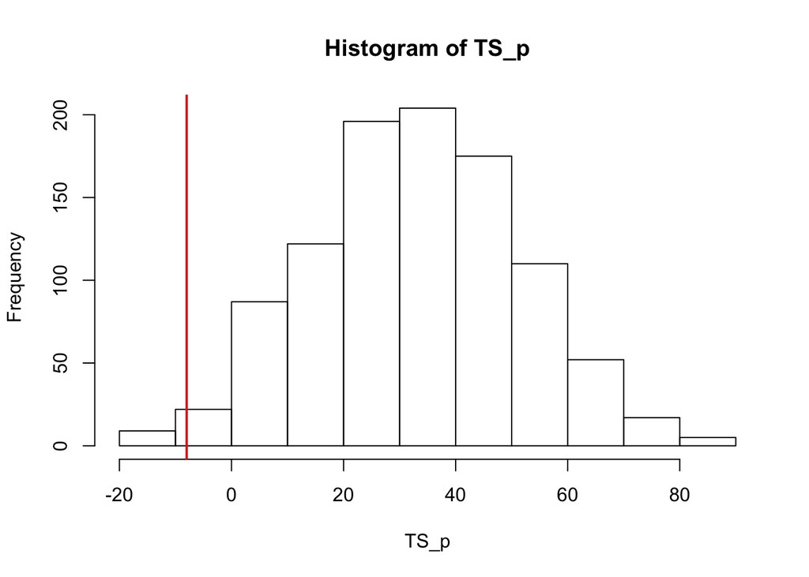

```r
lipids_w = lipids[lipids$isolate == 'warm',]
# several "homemade" TSs possible: difference of rank sums between samples, difference of sample means, difference of sample means weighted by variance, just the formula of the t-statistic anyway.
# rank(x) # to get ranks of a vector if such a transformation is desired
# sample(x) # creates a random permutation of x

# here we use a rank sum difference similar to the U-test

ranks<-rank(lipids_w$FA1_SAnb)
x1 = ranks[lipids_w$temperature == "6"] # ranks of response x for first temp treatment
x2 =  ranks[lipids_w$temperature == "28"] # same for second temp treatment
TS_emp<-sum(x1)-sum(x2) # computing TS=rank sum difference

TS_p<-numeric(999) # a vector to collect TS computed after permutation
for (i in 1:999) {
    temp_p = sample(lipids_w$temperature) # random assignment of temp to objects
    x1 = ranks[temp_p == "6"] # ranks of response x for first temp treatment
    x2 =  ranks[temp_p == "28"] # same for second temp treatment
    TS_p[i] = sum(x1)-sum(x2) # computing TS=rank sum difference
}
## null distribution of TSs
hist(TS_p)

# assess how likely your "empirical" TS is given this null distribution
# the "empirical" one is the TS computed for the unpermuted data!
abline(v = TS_emp, col='red', lwd=2)
```

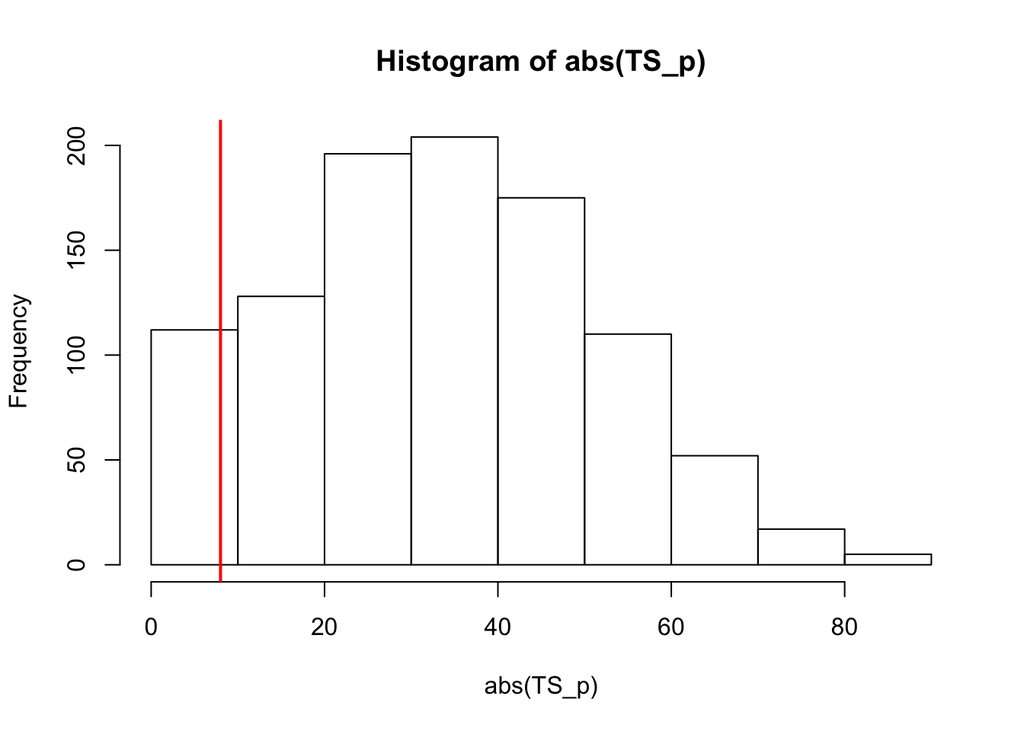

```r
##  how likely is a value as or more extreme than the observed if the null is true
## absolute values make this a two-sided test
hist(abs(TS_p))
abline(v = abs(TS_emp), col='red', lwd=2)
```

```r
## compute a p-value
sum(abs(TS_p) >= abs(TS_emp)) / 1000
```

```
## [1] 0.932
```

```r
## if we want to do a one-sided test
sum(TS_p <= TS_emp) / 1000 # change >/< depending on hypothesis
```

```
## [1] 0.011
```

Such permutation-based significance tests are a standard strategy in multivariate tests. Permutation is not always as simple as here (*complete*) and can be restrained to adequately test more complex designs with multiple factors and dependencies (random factors).

3. Compute dissimilarities with regard to fatty acid composition between isolates and temperature treatments using an adequate dissimilarity/distance measure. Explore dissimilarity among isolates and temperature treatments using a dendrogram. You will not only have to make a choice about transformation and the dissimilarity metric, but also decide about which linkage algorithm to use.

```r
library(vegan)
lipids2<-lipids[,grep("FA",names(lipids))] # choose only FA columns
apply(lipids2,1,sum) # confirm proportional data
```

```
##  [1] 1 1 1 1 1 1 1 1 1 1 1 1 1 1 1 1 1 1 1 1 1 1 1 1 1 1 1 1
```

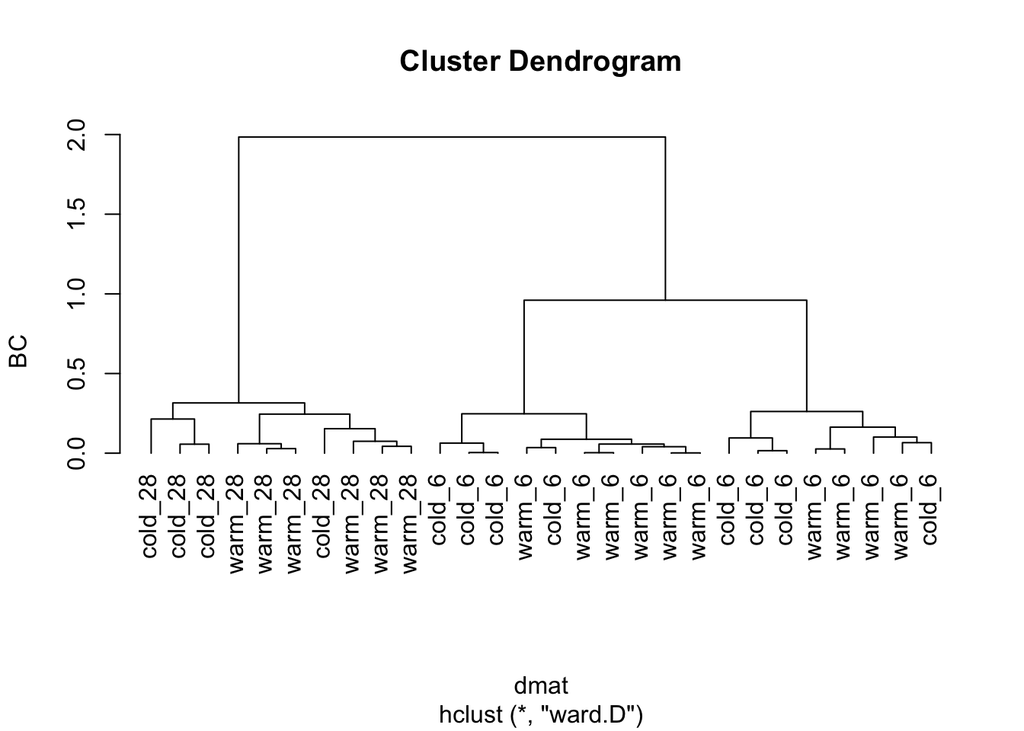

```r
dmat = vegdist(lipids2, method = "bray") # compute a dissimilarity matrix

clu_1<-hclust(dmat, method = "single") # one of many possible solutions, play with setting for method, check help(hclust)
clu_2<-hclust(dmat, method = "ward.D")

# then compare effect of agglomeration method on dendrogram
combifac<-paste(lipids$isolate,lipids$temperature,sep="_")
plot(clu_2, hang = -1, labels = combifac, ylab = "BC")
```

```r
names(clu_2)
```

```
## [1] "merge"       "height"      "order"       "labels"      "method"
## [6] "call"        "dist.method"
```

```r
# which agglomeration method (and thus dendrogram) is best?
cophenetic(clu_2) # linkage distances in dendrogram
```

```
##              1           2           3           4           5           6
## 2  0.026556443
## 3  0.163549451 0.163549451
## 4  0.163549451 0.163549451 0.101384615
## 5  1.984573082 1.984573082 1.984573082 1.984573082
## 6  1.984573082 1.984573082 1.984573082 1.984573082 0.043170829
## 7  1.984573082 1.984573082 1.984573082 1.984573082 0.074664668 0.074664668
## 8  0.960111977 0.960111977 0.960111977 0.960111977 1.984573082 1.984573082
## 9  0.960111977 0.960111977 0.960111977 0.960111977 1.984573082 1.984573082
## 10 0.960111977 0.960111977 0.960111977 0.960111977 1.984573082 1.984573082
## 11 0.960111977 0.960111977 0.960111977 0.960111977 1.984573082 1.984573082
## 12 0.960111977 0.960111977 0.960111977 0.960111977 1.984573082 1.984573082
## 13 0.960111977 0.960111977 0.960111977 0.960111977 1.984573082 1.984573082
## 14 1.984573082 1.984573082 1.984573082 1.984573082 0.245191335 0.245191335
## 15 1.984573082 1.984573082 1.984573082 1.984573082 0.245191335 0.245191335
## 16 1.984573082 1.984573082 1.984573082 1.984573082 0.245191335 0.245191335
## 17 0.261693224 0.261693224 0.261693224 0.261693224 1.984573082 1.984573082
## 18 0.261693224 0.261693224 0.261693224 0.261693224 1.984573082 1.984573082
## 19 0.261693224 0.261693224 0.261693224 0.261693224 1.984573082 1.984573082
## 20 0.163549451 0.163549451 0.066000000 0.101384615 1.984573082 1.984573082
## 21 1.984573082 1.984573082 1.984573082 1.984573082 0.315448858 0.315448858
## 22 0.960111977 0.960111977 0.960111977 0.960111977 1.984573082 1.984573082
## 23 0.960111977 0.960111977 0.960111977 0.960111977 1.984573082 1.984573082
## 24 0.960111977 0.960111977 0.960111977 0.960111977 1.984573082 1.984573082
## 25 0.960111977 0.960111977 0.960111977 0.960111977 1.984573082 1.984573082
## 26 1.984573082 1.984573082 1.984573082 1.984573082 0.153779887 0.153779887
## 27 1.984573082 1.984573082 1.984573082 1.984573082 0.315448858 0.315448858
## 28 1.984573082 1.984573082 1.984573082 1.984573082 0.315448858 0.315448858
##              7           8           9          10          11          12
## 2
## 3
## 4
## 5
## 6
## 7
## 8  1.984573082
## 9  1.984573082 0.057143832
## 10 1.984573082 0.087488181 0.087488181
## 11 1.984573082 0.057143832 0.040687171 0.087488181
## 12 1.984573082 0.003105828 0.057143832 0.087488181 0.057143832
```

[output cut: 85 more lines]

```
## 14
## 15
## 16
## 17
## 18
## 19
## 20
## 21
## 22
## 23
## 24
## 25
## 26 1.984573082
## 27 1.984573082 0.315448858
## 28 1.984573082 0.315448858 0.056444334
```

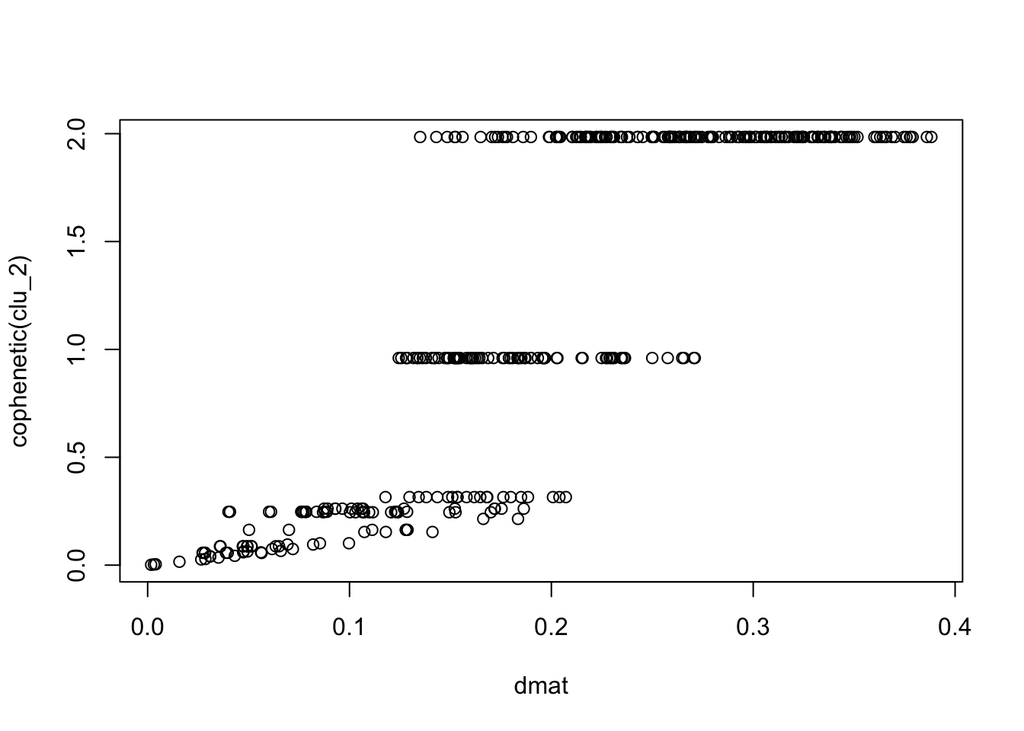

```r
plot(dmat,cophenetic(clu_2))
```

```r
cor(dmat,cophenetic(clu_2),method="spearman")
```

```
## [1] 0.8600969
```

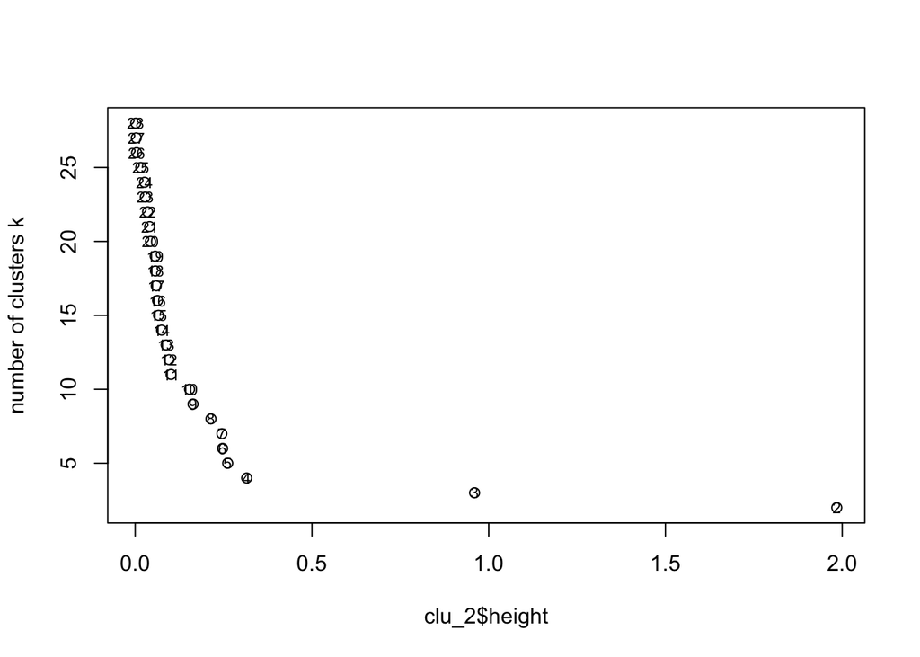

```r
# could compare several clustering methods with this

# define subgroups
plot(clu_2$height,nrow(lipids):2,,ylab="number of clusters k") # look for jumps to define a "cutting distance"
text(clu_2$height,nrow(lipids):2,labels=nrow(lipids):2,cex=0.7)
```

```r
cutree(clu_2,k=4) # gives a new grouping defined from dendrogram
```

```
##  [1] 1 1 1 1 2 2 2 3 3 3 3 3 3 2 2 2 1 1 1 1 4 3 3 3 3 2 4 4
```

```r
cutree(clu_2,h=0.5)
```

```
##  [1] 1 1 1 1 2 2 2 3 3 3 3 3 3 2 2 2 1 1 1 1 2 3 3 3 3 2 2 2
```

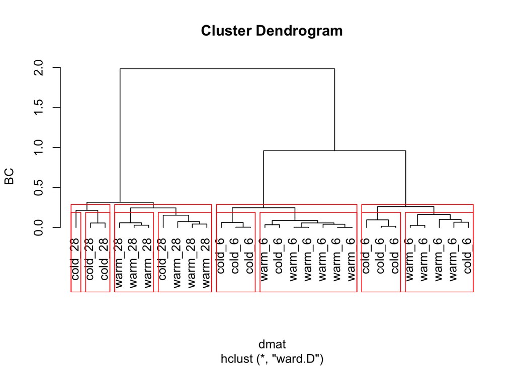

```r
# some more graphing options
plot(clu_2, hang = -1, labels = combifac, ylab = "BC")
rect.hclust(clu_2,k=4)
rect.hclust(clu_2,h=0.2)
```

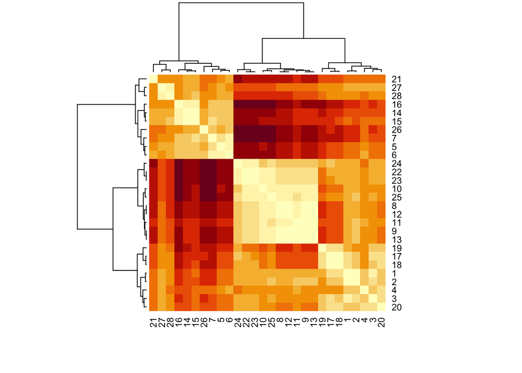

```r
# more plotting and cutting options with dendrogram()
lipids_dend<-as.dendrogram(clu_2)
heatmap(as.matrix(dmat),Rowv=lipids_dend,symm=TRUE)
```

Choose a final dendrogram. Which problems have you encountered? > Final dendrogram solution is quite dependent on choice of agglomeration method.

```r
pcoa = cmdscale(dmat, k = 2, eig=TRUE) # always computes all axes, but will only report scores of k=2
pcoa$eig # to assess importance of axes
```

```
##  [1]  4.679613e-01  1.218300e-01  3.495617e-02  2.240330e-02  1.744048e-02
##  [6]  1.059179e-02  9.893267e-03  5.954693e-03  4.683116e-03  2.379895e-03
## [11]  1.839059e-03  8.843655e-04  6.979334e-04  2.430638e-04  3.639854e-05
## [16]  4.621521e-06 -4.049500e-18 -2.081441e-05 -1.920630e-04 -5.183094e-04
## [21] -6.788811e-04 -1.218277e-03 -1.809083e-03 -2.607283e-03 -3.368888e-03
## [26] -4.709655e-03 -8.248372e-03 -1.765893e-02
```

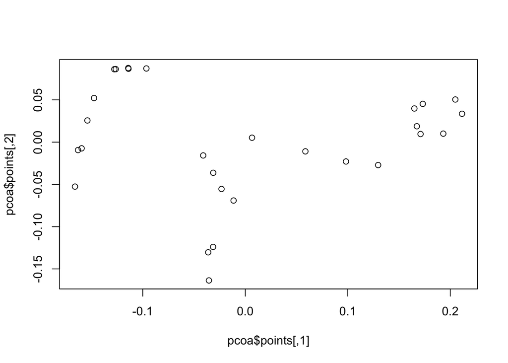

```r
# note some negative eigenvalues (variances!) for less important axes caused by squeezing the semimetric BC into a Euclidean space

plot(pcoa$points) # score plot
```

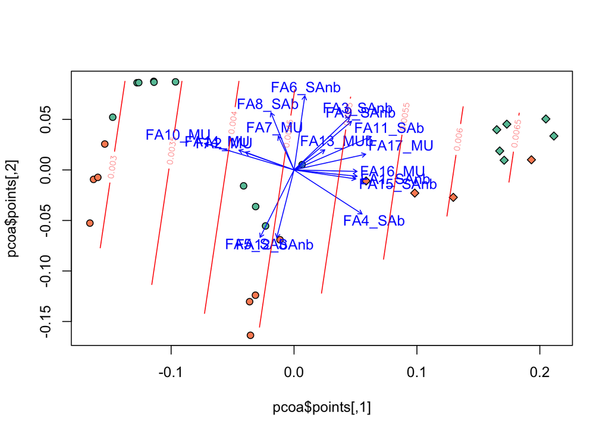

```
##
## Family: gaussian
## Link function: identity
##
## Formula:
## y ~ s(x1, x2, k = 10, bs = "tp", fx = FALSE)
##
## Estimated degrees of freedom:
## 1.79  total = 2.79
##
## REML score: -126.8288
```

```r
# use isolate and temperature information to color and set point characters

pch.temperature <- as.integer(as.character(lipids$temperature))
pch.temperature[pch.temperature==6]<-21
pch.temperature[pch.temperature==28]<-23

library(RColorBrewer)
cols = brewer.pal(8, "Set2")
col.isolate = as.character(lipids$isolate)
col.isolate[col.isolate == "warm"] = cols[1]
col.isolate[col.isolate == "cold"] = cols[2]

plot(pcoa$points,pch=pch.temperature,bg=col.isolate) # score plot

# to show variables
plot(envfit(pcoa,env=lipids2))
ordisurf(x=pcoa,y=lipids2$FA1_SAnb,add=TRUE) # as contourplot
```

**Bonus**: Compare PCoA results with results of a PCA on the raw data.

5. For non-metric dissimilarities an often more appropriate ordination is created by searching for a low-dimensional configuration whose distances reproduce the **rank order** of observed dissimilarities. Use such a non-metric multidimensional scaling on a more appropriate Bray-Curtis dissimilarity matrix. How many dimensions do you need for an adequate representation of the data? Produce a nice graph demonstrating differences between isolates and temperatures. Which fatty acids drive the differences (or: are typical for specific treatments)?

```r
mds_lipids = metaMDS(comm = lipids2, distance = "bray", k = 2, trymax = 100) # to run a NMDS, $points to get scores, $stress to get information about fit
```

```
## *** Solution reached
```

```r
mds_lipids$stress
```

```
## [1] 0.06291168
```

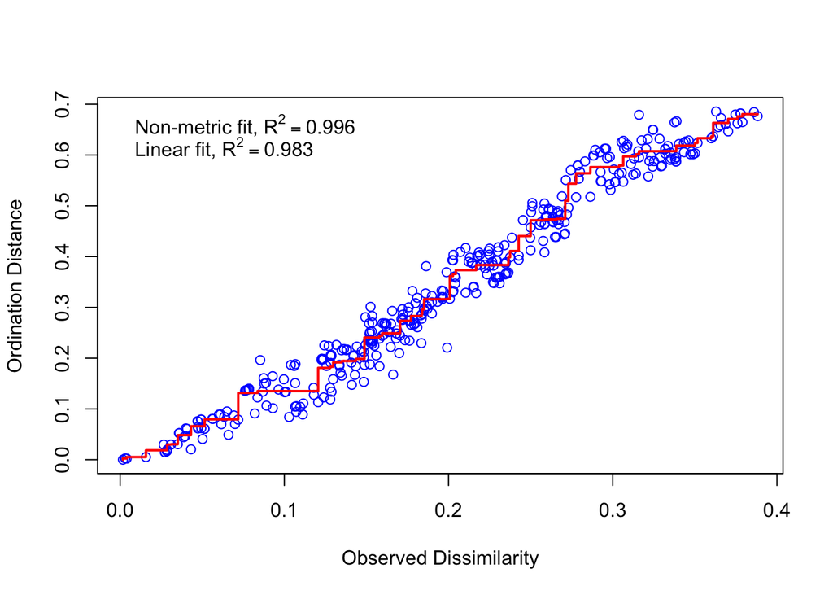

```r
## % of dissimilarities unrepresented

stressplot(mds_lipids) # to compare configuration distances with dissimilarities
```

```r
goodness(mds_lipids) # sample-specific goodness of fit
```

```
##  [1] 0.011061697 0.013697002 0.007606636 0.017970970 0.012576055 0.014203368
##  [7] 0.008087145 0.009154933 0.009137155 0.008889396 0.011453534 0.010106809
## [13] 0.009137155 0.010449475 0.011982115 0.013634723 0.011813143 0.011758804
## [19] 0.017537947 0.016442182 0.017082034 0.005768756 0.005300901 0.008718055
## [25] 0.007322781 0.013383239 0.011960313 0.013389705
```

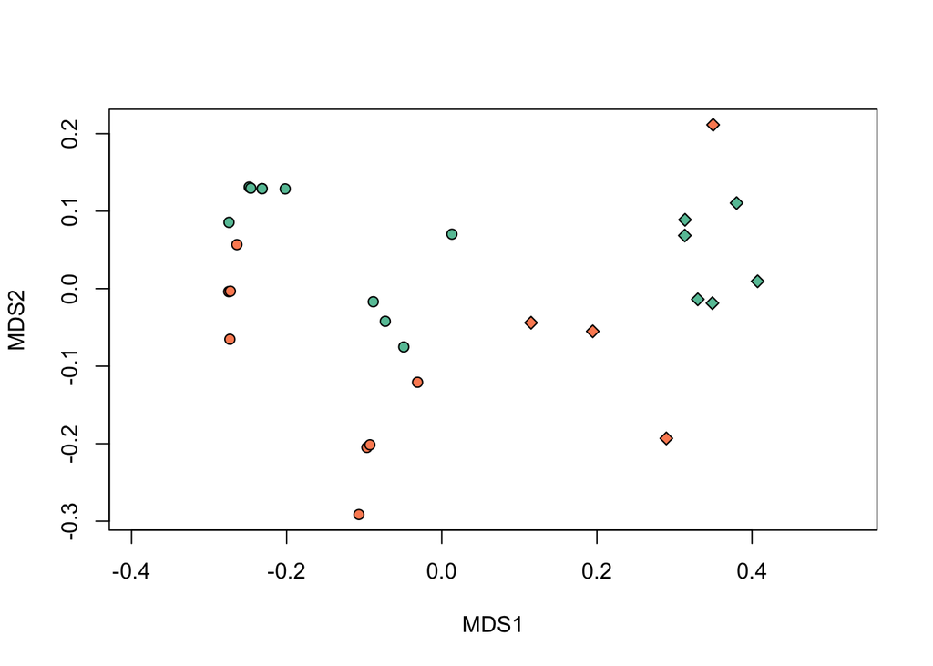

```r
plot(mds_lipids$points,asp=1,pch=pch.temperature,bg=col.isolate)
```

```r
# to define space using the variables
wascores(mds_lipids$points,lipids2) # variables as weighted averages of site (=sample) scores
```

```
##                  MDS1          MDS2
## FA1_SAnb   0.08265525 -0.0006282335
## FA2_MU    -0.25892347  0.0314240784
## FA3_SAnb   0.04411120  0.0093910975
## FA4_SAb    0.04960835 -0.0122541395
## FA5_SAb   -0.06030828 -0.0359838166
## FA6_SAnb   0.02147540  0.0365523704
## FA7_MU    -0.24730344  0.1304299380
## FA8_SAb   -0.03171335  0.0187091088
## FA9_SAnb   0.10625120  0.0204947147
## FA10_MU   -0.06585539  0.0064562012
## FA11_SAb   0.26779336  0.0144335329
## FA12_SAnb -0.05687334 -0.0520078997
## FA13_MUb   0.07823343  0.0110658883
## FA14_MU   -0.26373878  0.0343438526
## FA15_SAnb  0.08740716  0.0031803659
## FA16_MU    0.12002364  0.0285584461
## FA17_MU    0.10550587  0.0068332123
```

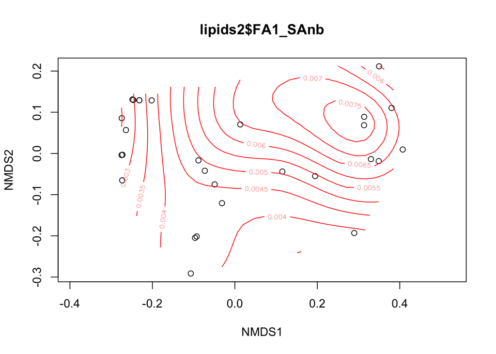

```
##
## Family: gaussian
## Link function: identity
##
## Formula:
## y ~ s(x1, x2, k = 10, bs = "tp", fx = FALSE)
##
## Estimated degrees of freedom:
## 5.39  total = 6.39
##
## REML score: -127.2085
```

```r
ordisurf(x=mds_lipids,y=lipids2$FA1_SAnb) # as contourplot
```

```r
envfit(mds_lipids,env=lipids2) # take care: behaviour of variables not necessarily monotonous in ordination space
```

```
##
## ***VECTORS
##
##              NMDS1    NMDS2     r2 Pr(>r)
## FA1_SAnb   0.99951 -0.03146 0.4225  0.001 ***
## FA2_MU    -0.89350  0.44906 0.2671  0.013 *
## FA3_SAnb   0.75011  0.66131 0.7002  0.001 ***
## FA4_SAb    0.69905 -0.71507 0.8587  0.001 ***
## FA5_SAb   -0.37516 -0.92696 0.8236  0.001 ***
## FA6_SAnb   0.14047  0.99009 0.6259  0.001 ***
## FA7_MU    -0.41630  0.90923 0.1684  0.082 .
## FA8_SAb   -0.37882  0.92547 0.3707  0.005 **
## FA9_SAnb   0.78134  0.62411 0.6882  0.001 ***
## FA10_MU   -0.92655  0.37616 0.9731  0.001 ***
## FA11_SAb   0.97599  0.21784 0.8046  0.001 ***
## FA12_SAnb -0.25532 -0.96686 0.6269  0.001 ***
## FA13_MUb   0.86287  0.50542 0.1544  0.100 .
## FA14_MU   -0.88018  0.47464 0.3352  0.003 **
## FA15_SAnb  0.98884  0.14900 0.4024  0.003 **
## FA16_MU    0.71231  0.70186 0.4922  0.001 ***
## FA17_MU    0.96586  0.25905 0.5745  0.001 ***
## ---
## Signif. codes:  0 '***' 0.001 '**' 0.01 '*' 0.05 '.' 0.1 ' ' 1
## Permutation: free
## Number of permutations: 999
```

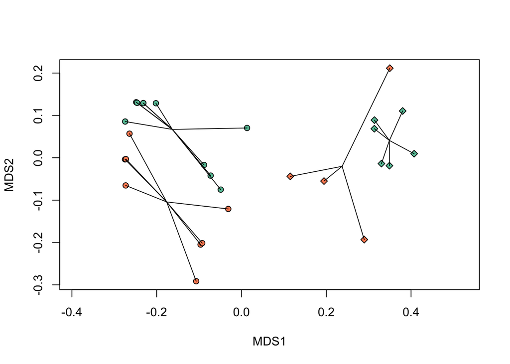

```r
# some more useful graphical tools
plot(mds_lipids$points,asp=1,pch=pch.temperature,bg=col.isolate)
ordispider(mds_lipids,combifac)
```

```r
ordihull()
```

```
## Error in scores(ord, display = display, ...): argument "ord" is missing, with no default
```

```r
ordiellipse()
```

```
## Error in scores(ord, display = display, ...): argument "ord" is missing, with no default
```

```r
ordicluster()
```

```
## Error in weights(ord, display): argument "ord" is missing, with no default
```

6. The results clearly suggest differences in fatty acid composition due to isolate and temperature. Specify hypotheses for these two main effects and a potential interaction. Test using PERMANOVA. Just like in ANOVA, where variance homogeneity is of interest, here we should check multivariate variance (*cloud shape*) known as *dispersion*.

> H0 isolate affects fatty acid composition, H0 temp affects fatty acid composition, H0 temp effect on fatty acid composition differs between isolates

```r
bd<-betadisper(dmat,group=combifac) # to test dispersion, works only with one factor
anova(bd) # test for dispersion differences
```

```
## Analysis of Variance Table
##
## Response: Distances
##           Df   Sum Sq   Mean Sq F value Pr(>F)
## Groups     3 0.004967 0.0016556  0.8283 0.4913
## Residuals 24 0.047972 0.0019988
```

```r
anova(lm(bd$distances~isolate*temperature,data=lipids))
```

```
## Analysis of Variance Table
##
## Response: bd$distances
##                     Df   Sum Sq   Mean Sq F value Pr(>F)
## isolate              1 0.003778 0.0037778  1.8900 0.1819
## temperature          1 0.000110 0.0001098  0.0549 0.8167
## isolate:temperature  1 0.001079 0.0010794  0.5400 0.4695
## Residuals           24 0.047972 0.0019988
```

```r
adonis(dmat~isolate*temperature,data=lipids) # PERMANOVA, just use like aov() or lm()
```

```
##
## Call:
## adonis(formula = dmat ~ isolate * temperature, data = lipids)
##
## Permutation: free
## Number of permutations: 999
##
## Terms added sequentially (first to last)
##
##                     Df SumsOfSqs MeanSqs F.Model      R2 Pr(>F)
## isolate              1   0.06599 0.06599   7.988 0.09987  0.002 **
## temperature          1   0.38394 0.38394  46.476 0.58105  0.001 ***
## isolate:temperature  1   0.01258 0.01258   1.522 0.01903  0.202
## Residuals           24   0.19826 0.00826         0.30005
## Total               27   0.66077                 1.00000
## ---
## Signif. codes:  0 '***' 0.001 '**' 0.01 '*' 0.05 '.' 0.1 ' ' 1
```